# Statistics Homework Practice Questions

- A note about rounding values:
  - The best practice is to avoid rounding whenever possible. When you ultimately attempt the statistics homework, you should input the most precise answer you can. i.e., Don’t round.
  - Please note that, in order to facilitate easier reading, some of the displayed solutions below do contain a small amount of rounding error.
- If you find a typo or mistake on this sheet, please let the instructor know.
- **Feel free to ask for assistance if there’s anything you find challenging or unclear. Being proactive about seeking help is a key to success!**
- Your graded statistics homework will be available on Monday, February 10th (midterm week), and is due Friday February 14th by 23:59. You can save your progress and return to it anytime before the deadline.

# Question 1.

## Calculate the mean, sum of squared deviations (SS), variance, and standard deviation for the following set of numbers and assume they represent an entire *population*:

$x = [6,9,0,4,7,-4]$

**Click here for solution**

**Mean ($\mu$):**
$$\mu = \frac{\sum(x)}{n} =
\frac{6 + 9 + 0 + 4 + 7 + -4}{6} =
3.667$$

**Sum of Squared Deviations ($SS$):**

$\begin{aligned} (x - \mu)^2 &= \\ (6 - 3.667)^2 &= 5.443 \\ (9 - 3.667)^2 &= 28.441 \\ (0 - 3.667)^2 &= 13.447 \\ (4 - 3.667)^2 &= 0.111 \\ (7 - 3.667)^2 &= 11.109 \\ (-4 - 3.667)^2 &= 58.783 \end{aligned}$

$\begin{aligned} SS &= \sum(x - \mu)^2 \\ &= 5.443 + 28.441 + 13.447 + 0.111 + 11.109 + 58.783 \\ &= 117.334 \end{aligned}$

**Population Variance ($\sigma^2$):**

$\sigma^2 = \frac{\sum(x - \mu)^2}{N} = \frac{117.334}{6} = 19.556$

**Population Standard Deviation ($\sigma$):**

$\sigma = \sqrt{\frac{\sum(x - \mu)^2}{N}} = \sqrt{\frac{117.334}{6}} = 4.422$

# Question 2.

## Assume the data from Question 1 is normally distributed, calculate the interval the middle 95% of the data fall within.

**Click here for solution**

From question 1:

$\mu = 3.667$

$\sigma = 4.422$

The middle 95% is **two** standard deviations from the mean. Thus . . .

$\begin{aligned} 3.667 - 2 \times 4.422 &= -5.177\\ 3.667 + 2 \times 4.422 &= 12.511\\ \end{aligned}$

The middle 95% of the data fall within the interval $[-5.177, 12.511]$.

# Question 3.

## Assume the data from Question 1 is normally distributed, calculate the interval the middle 68% of the data fall within.

**Click here for solution**

From question 1:

$\mu = 3.667$

$\sigma = 4.422$

The middle 68% is **one** standard deviation from the mean. Thus . . .

$\begin{aligned} 3.667 - 1 \times 4.422 &= -0.755\\ 3.667 + 1 \times 4.422 &= 8.089\\ \end{aligned}$

The middle 68% of the data fall within the interval $[-0.755, 8.089]$.

# Question 4.

## Calculate the mean, sum of squared deviations (SS), variance, and standard deviation for the following set of numbers and assume they represent a *sample* of data:

$x = [161,195,110,127,113,104]$

**Click here for solution**

**Mean ($\bar{x}$):**
$$\bar{x} = \frac{\sum(x)}{n} =
\frac{161 + 195 + 110 + 127 + 113 + 104}{6} =
135$$

**Sum of Squared Deviations ($SS$):**

$\begin{aligned} (x - \bar{x})^2 &= \\ (161 - 135)^2 &= 676 \\ (195 - 135)^2 &= 3600 \\ (110 - 135)^2 &= 625 \\ (127 - 135)^2 &= 64 \\ (113 - 135)^2 &= 484 \\ (104 - 135)^2 &= 961 \end{aligned}$

$\begin{aligned} SS &= \sum(x - \bar{x})^2 \\ &= 676 + 3600 + 625 + 64 + 484 + 961 \\ &= 6410 \end{aligned}$

**Sample Variance ($s^2$):**

$s^2 = \frac{\sum(x - \bar{x})^2}{N-1} = \frac{6410}{5} = 1282$

**Sample Standard Deviation ($s$):**

$s = \sqrt{\frac{\sum(x - \bar{x})^2}{N-1}} = \sqrt{\frac{6410}{5}} = 35.805$

# Question 5.

## Assume the data from Question 4 is normally distributed, calculate the interval the middle 95% of the data fall within.

**Click here for solution**

From question 4:

$\bar{x} = 135$

$s = 35.805$

The middle 95% is **two** standard deviations from the mean. Thus . . .

$\begin{aligned} 135 - 2 \times 35.805 &= 63.39\\ 135 + 2 \times 35.805 &= 206.61\\ \end{aligned}$

The middle 95% of the data fall within the interval $[63.39, 206.61]$.

# Question 6.

## Assume the data from Question 4 is normally distributed, calculate the interval the middle 99.7% of the data fall within.

**Click here for solution**

From question 4:

$\bar{x} = 135$

$s = 35.805$

The middle 99.7% is **three** standard deviations from the mean. Thus . . .

$\begin{aligned} 135 - 3 \times 35.805 &= 27.585\\ 135 + 3 \times 35.805 &= 242.415\\ \end{aligned}$

The middle 99.7% of the data fall within the interval $[27.585, 242.415]$.

# Question 7.

## The sample mean and sample standard deviation of the numbers $[11,14,5,9,12]$ is $10.2$ and $3.421$ respectively. What happens to the mean and standard deviation if each of the five numbers is multiplied by $2$?

**Click here for solution**

Both the mean and the standard deviation are also multiplied by $2$.

$\bar{x} = 10.2 \times 2 = 20.4$

$s = 3.421 \times 2 = 6.842$

# Question 8.

## What happens to the mean and population standard deviation of question 7’s data if each of the five numbers has $5$ added to it?

# Question 9.

## Bobby’s brother constantly tells him he’s abnormal. To prove this, his brother obtained the test scores of Bobby and his classmates.

## His classmates scored $70, 68, 75, 72, 76, 74, 69, 82, 73$.

## Bobby scored a $56$.

## If “abnormal” is operationally defined as being at least $2$ standard deviations away from the mean, is Bobby abnormal? (Use population level statistics).

**Click here for solution**

Calculating $z$ (i.e., a “z-score”) will tell you how far (in standard deviations) a specific value is from the mean.

*Make sure to include Bobby in your calculation of the mean and standard deviation because he is a member of the class too!*

The mean and standard deviation of this data set are:

$\mu = 71.5$

$\sigma = 6.423$

Therefore:

$z = \frac{x_i - \mu}{\sigma} = \frac{56 - 71.5}{6.423} = -2.413$

Bobby’s score is 2.413 standard deviations **below** the mean (because $z$ is negative). Since $2.413$ is greater than $2$, Bobby’s brother is (technically) correct. Bobby is abnormal.

Another approach to solving this would be to calculate the middle 95% interval and see if Bobby’s score falls outside of it.

# Question 10.

## Given question 9, what range of scores would Bobby need to fall within to be considered “normal”?

**Click here for solution**

“Abnormal” here is being defined as greater than $2$ standard deviations away from the mean. Thus the interval to be considered normal is . . .

$\begin{aligned} 71.5 - 2 \times 6.423 = 58.654\\ 71.5 + 2 \times 6.423 = 84.346 \end{aligned}$

$[58.654, 84.346]$

# Question 11.

## What is the population mean, sum of squared deviations (SS), variance, and standard deviation for the following distribution of numbers: 4, 4, 4, 4, 4, 4, and 4? Why do you think the answer turned out the way it did?

**Click here for solution**

$\begin{aligned} &\mu = 4.0 \\ &SS = 0.0 \\ &\sigma^2 = 0.0 \\ &\sigma = 0.0 &\end{aligned}$

The data has no spread (i.e. does not vary/deviate); hence our statistical measures of spread (the sum of squared deviations, variance, and standard deviation) are just 0.

# Question 12.

## Calculate the mean, median, and mode of the following numbers:

$40,40,34,38,30,31,32,34,32,35,37,36,31,30,$ $39,35,37,38,33,40,37,39,37,36,31,40,33$

**Click here for solution**

Mean = $35.37$

Median = $36$

Mode = Bimodal: $40$ and $37$

# Question 13.

## A researcher had five different groups of rats in an experiment. Each group of rats was given a different dosage of caffiene. The number of rats in each group and their dosage in milligrams (mg) is below. What was the average dose of caffeine across all the rats?

| Group | Rats | Dose |
| --- | --- | --- |
| Control | 10 | 0 |
| A | 7 | 4 |
| B | 9 | 8 |
| C | 6 | 16 |
| D | 5 | 32 |

To make your life easier, you might want to read up on weighted means:

- https://www.mathsisfun.com/data/weighted-mean.html

**Click here for solution**

**Using a Weighted Mean:**

$\frac{10 \times 0 + 7 \times 4 + 9 \times 8 + 6 \times 16 + 5 \times 32} {10 + 7 + 9 + 6 + 5} = \frac{356}{37} = 9.622$

**Using the Conventional Mean:**

$\frac{0+0+0+0+0+0+0+0+0+0+4+4+4+4+4+4+4+8+8+8+8+8+8+8+8+8+16+16+16+16+16+16+32+32+32+32+32}{37} = \frac{356}{37} = 9.622$

# Question 14.

## Use the following histogram to answer a and b:

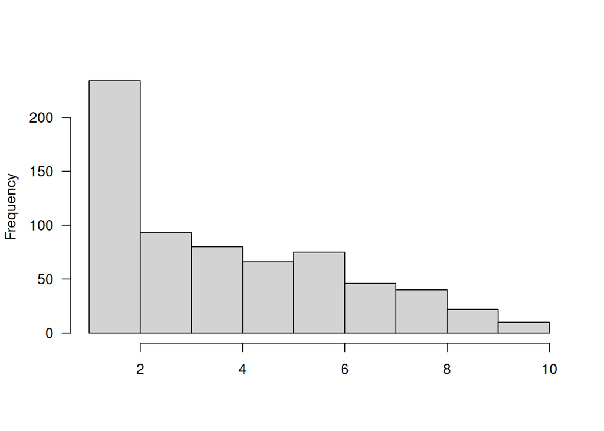

## Describe the skew and modality Use inequalities to state the relationship between the mode, median, and mean?

- Note: [inequalities](https://www.mathsisfun.com/algebra/inequality.html) are just *greater than* ($>$) and *less than* ($<$) signs.

**Click here for solution**

1. Positively Skewed & unimodal
2. Mode < Median < Mean

# Question 15.

## The average GPA of students in 2001 at a private university was 3.37. A survey on a sample of 203 students from this university yielded an average GPA of 3.59 a decade later. Identify which value represents a sample mean and which value represents a population mean.

**Click here for solution**

$\bar{x} = 3.59$

$\mu = 3.37$

# Question 16.

## Use the histogram below to answer the following questions:

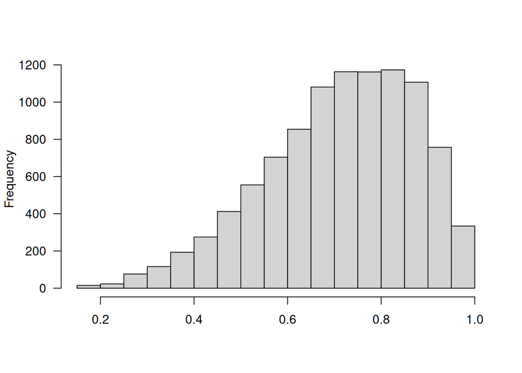

## State whether you expect the mean to be higher or lower than the median. State whether the mean or median would better represent a typical observation in the data and why. State whether you should use standard deviation to as a measure of spread and why.

**Click here for solution**

1. The mean will be lower.
2. Median. It is robust to the extreme values in the left tail. i.e. The extreme values in the tail would pull the mean away from a reasonable estimate of the central tendency.
3. You should not. The data is skewed and, like the mean, the standard deviation is heavily influenced by extreme values.

# Question 17.

## Alexa rolled a six-sided die a bunch of times and plotted the values on the histogram below. What are the following values of this data:

$\mu$, $\bar{x}$, $\sigma^2$, $s^2$?

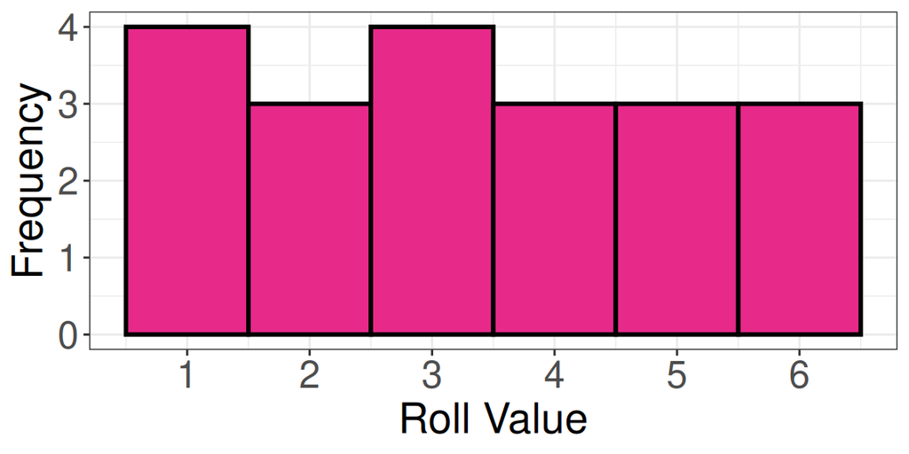

**Click here for solution**

Each bar shows the number of times a certain value was rolled. Therefore . . .

**Population and Sample Means ($\mu$, $\bar{x}$):**

Note that there is no difference between how you calculate a population vs. sample mean.

$\frac{1+1+1+1+2+2+2+3+3+3+3+4+4+4+5+5+5+6+6+6}{20} = \frac{67}{20} = 3.35$

- *Note: this could have been calculated more simply using a weighted mean.*

**Population and Sample Variance ($\sigma^2$, $s^2$):**

First calculate the sum of squared deviations ($SS$) for all the values:

$SS = 58.55$

Then use that to calculate both versions of the variance…

$\sigma^2 = \frac{58.55}{20} = 2.927$

$s^2 = \frac{58.55}{19} = 3.082$

# Question 18.

## Kristi scored $62.5$. Her other classmates obtained the following scores:

$60.5, 80.1, 70.5, 62.5, 56.5$

## How many standard deviations above or below the mean was Kristi in her class? Use population level statistics for this question and make sure to specify the sign (+ or -) of the value you obtain.

**Click here for solution**

To solve this you need to first calculate the mean and **population** standard deviation. And when you calculate these numbers, make sure Kristi is included.

$\mu = 65.433$

$\sigma = 7.769$

$z = \frac{x_i - \mu}{\sigma} = \frac{62.5 - 65.433}{7.769} = -0.378$

Kristi is $0.378$ standard deviations **below** the mean.

# Question 19.

## People with IQ scores $2$ standard deviations above the mean or higher are often classified as “genius”. If IQ scores have a mean of $100$ and a standard deviation of $15$, what is the minimum IQ score you would need to qualify as a genius?

**Click here for solution**

Input the values you know into the z-score formula and then solve for $x$:

$\begin{aligned} \frac{x - \mu}{\sigma} &= z \\ \\ \frac{x - 100}{15} &= 2 \\ \\ x - 100 &= 2 \times 15 \\ \\ x &= 2 \times 15 + 100 \\ \\ x &= 130 \end{aligned}$

# Question 20.

## Brittany records the speeds of vehicles moving past their house. The speed limit is $40\text{ km/h}$. The mean and standard deviation of $132$ readings was $\bar{x} = 43 \text{ km/h}$ and $s = 5.2 \text{ km/h}$.

## Assuming the data is normally distributed, what is the percent chance (approximately) that a person is travelling **faster** than $45.6 \text{ km/h}$?

## Use this Standard Normal Distribution curve to help answer the question:

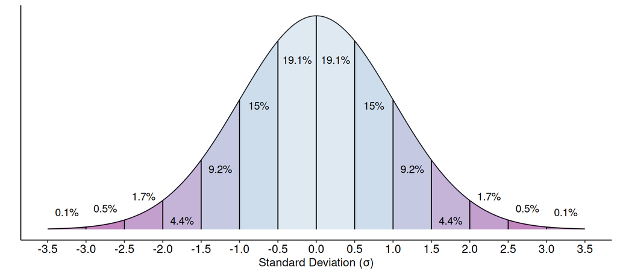

**Click here for solution**

The first step is to figure out how many standard deviations above or below the mean $45.6 \text{ km/h}$ is.

$z = \frac{45.6 - 43}{5.2} = 0.5$

Then, find that point ($0.5$) on the curve’s x-axis and add up all the percentages to the **right** of that point since those would encompass values *faster* than 45.6 km/h.

$15+9.2+4.4+1.7+0.5+0.1 = 30.9 \%$

# Question 21.

## From question 20, what is the percent chance that a person is travelling **slower** than $45.6 \text{ km/h}$?

**Click here for solution**

Find $0.5$ on the curve’s x-axis and add up all the percentages to the **left** of that point.

$0.1+0.5+1.7+4.4+9.2+15+19.1+19.1 = 69.1 \%$

# Question 22.

## In 1914 the famed Albertan sasquatch hunter, Balthazar Mulder Catchkins, compared the cranial capacity of $72$ sasquatch he had tracked during his illustrious carreer of squatching.

## The estimated capacity of the $72$ different sasquatch skulls he measured was normally distributed with a mean of $2167$ cubic centimeters and sample standard deviation of $86.63$.

## Approximately how many sasquatch in Catchkins’s sample would you expect to have cranial capcity between $2253.63$ $\text{cm}^3$ and $2340.26$ $\text{cm}^3$?

## Use this Standard Normal Distribution curve to help answer the question:

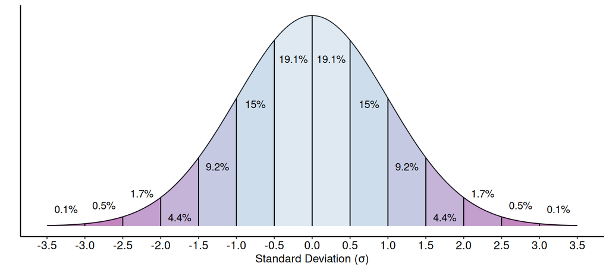

**Click here for solution**

The first step is to determine how many standard deviations from the mean the two values are:

$z_{low} = \frac{2253.63 - 2167}{86.63} = 1$

$z_{high} = \frac{2340.26 - 2167}{86.63} = 2$

Using the graph, establish the percentage both values encompass:

Between $1$ and $2$ standard deviations, we would add up the following percentages:

$9.2+4.4 = 13.6 \%$

Finally, calculate how much of the sample size this value represents:

$\left ( \frac{13.6}{100} \right ) \times 72 = 9.792$

# Question 23.

## Consider a normal probability distribution like the ones graphed above in questions 20 and 22. If you randomly select a value from a normal distribution, what do you think the probability of selecting a value **exactly** equal to the mean ($\mu$) is? (no calculations are needed to answer this)

**Click here for solution**

The probability is $0$.

This is because the normal distribution represents *continuous* data. Consequently, the mean, as a single point on that distribution, is infinitesimally small with an infinite amount of values on either side of it. And it is so small that the probability of getting a value *exactly* equal to it is just zero.

This holds true for any single point on a continuous distribution, like the normal distribution. This is why we talk about the probability of a *range* of values when using the normal distribution.

# Question 24.

## What numbers must be included with the following set of numbers to change their current median by $78.5$ in any direction?

$618, 691, 99$

## Choose the correct answer from one of these four options:

#### $300, 809, 986$ $439, 31, 888$ $364, 243, 730$ $702, 866, 802$

**Click here for solution**

Answering this question will require a bit of trial and error.

First, the median of the given three numbers is: $618$

- i.e., “$618, 691, 99$” has a median of $618$.

Second, the median of the given three numbers combined with the numbers from option **d** is equal to $696.5$.

- i.e., $618, 691, 99, 702, 866, 802$ has a median of $696.5$.

Note that the change (i.e., absolute difference) in median values is $|618 - 696.5| = 78.5$, therefore answer d is correct. If you try this with the other options you will find that the change (i.e., difference) in median values is not 78.5.

If you are wondering what the vertical line (|) brackets are, they indicate “[absolute value](https://www.mathsisfun.com/numbers/absolute-value.html).” I used this because we don’t care about the direction (positive or negative) of the change is. In simple terms, absolute values make everything positive.

# Question 25.

## Suppose the mean score on an exam is $59.1$ with a standard deviation of $5.1$ and that you score $0.3$ standard deviations **below** the mean, what was your raw score?

**Click here for solution**

Put the values in the z-score formula and solve for $x$.

$\begin{aligned} \frac{x - \bar{x}}{s} &= z \\ \\ \frac{x - 59.1}{5.1} &= -0.3 \\ \\ x - 59.1 &= -0.3 \times 5.1 \\ \\ x &= -0.3 \times 5.1 + 59.1 \\ \\ x &= 57.57 \end{aligned}$

# Question 26.

## Which distribution contains the largest spread/variability?

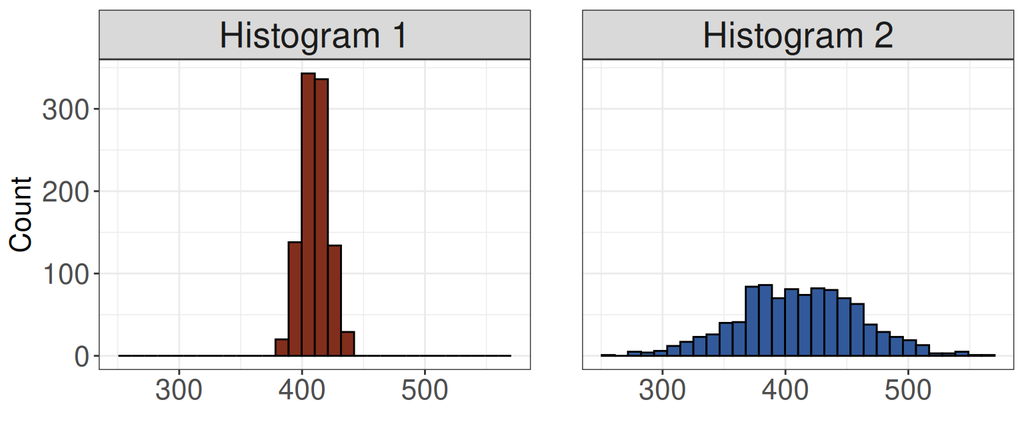

**Click here for solution**

Histogram 2. You can tell because it spans a much larger width of the x-axis values.

# Question 27.

## Which distribution contains the largest spread/variability?

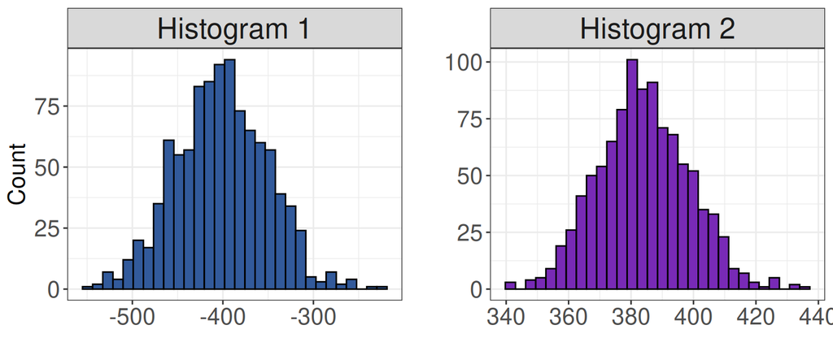

**Click here for solution**

Histogram 1. Similar to the previous question, this histogram spans a much larger width of the x-axis values. However, in this case, the scale of the two histograms are not equated. This makes it impossible to *see* any difference in the spread. Consequently, you need to rely on the values presented on the x-axis to answer this.